# Credit Card Churn Analysis Using Logistic Regression and Power BI

Tuba Khanam

2026-06-22

# Executive Summary

Customer churn refers to customers discontinuing the use of a company’s products or services. In the banking industry, retaining customers is important because acquiring new customers is generally more expensive than retaining existing ones.

This project analyzes credit card customer data to identify factors associated with customer churn and develops a Logistic Regression model to predict whether a customer is likely to leave the bank. Power BI is used to create an interactive dashboard for visualizing customer behavior and churn patterns.

# Business Problem

Customer attrition negatively impacts revenue and profitability. The objective of this project is to:

- Understand customer churn behavior.
- Identify factors influencing churn.
- Build a predictive model for churn prediction.
- Generate business recommendations for customer retention.

# Loading Required Libraries

```r
library(ggplot2)
library(dplyr)
library(readxl)
```

# Data Loading

```r
churn <- read_excel("D:/New folder/Downloads/archive/BankChurners.xlsx")

head(churn)
```

```
## # A tibble: 6 × 23
##   CLIENTNUM Attrition_Flag   Customer_Age Gender Dependent_count Education_Level
##       <dbl> <chr>                   <dbl> <chr>            <dbl> <chr>
## 1 768805383 Existing Custom…           45 M                    3 High School
## 2 818770008 Existing Custom…           49 F                    5 Graduate
## 3 713982108 Existing Custom…           51 M                    3 Graduate
## 4 769911858 Existing Custom…           40 F                    4 High School
## 5 709106358 Existing Custom…           40 M                    3 Uneducated
## 6 713061558 Existing Custom…           44 M                    2 Graduate
## # ℹ 17 more variables: Marital_Status <chr>, Income_Category <chr>,
## #   Card_Category <chr>, Months_on_book <dbl>, Total_Relationship_Count <dbl>,
## #   Months_Inactive_12_mon <dbl>, Contacts_Count_12_mon <dbl>,
## #   Credit_Limit <dbl>, Total_Revolving_Bal <dbl>, Avg_Open_To_Buy <dbl>,
## #   Total_Amt_Chng_Q4_Q1 <dbl>, Total_Trans_Amt <dbl>, Total_Trans_Ct <dbl>,
## #   Total_Ct_Chng_Q4_Q1 <dbl>, Avg_Utilization_Ratio <dbl>,
## #   Naive_Bayes_Classifier_Attrition_Flag_Card_Category_Contacts_Count_12_mon_Dependent_count_Education_Level_Months_Inactive_12_mon_1 <dbl>, …
```

# Dataset Structure

```r
str(churn)
```

```
## tibble [10,127 × 23] (S3: tbl_df/tbl/data.frame)
##  $ CLIENTNUM                                                                                                                         : num [1:10127] 7.69e+08 8.19e+08 7.14e+08 7.70e+08 7.09e+08 ...
##  $ Attrition_Flag                                                                                                                    : chr [1:10127] "Existing Customer" "Existing Customer" "Existing Customer" "Existing Customer" ...
##  $ Customer_Age                                                                                                                      : num [1:10127] 45 49 51 40 40 44 51 32 37 48 ...
##  $ Gender                                                                                                                            : chr [1:10127] "M" "F" "M" "F" ...
##  $ Dependent_count                                                                                                                   : num [1:10127] 3 5 3 4 3 2 4 0 3 2 ...
##  $ Education_Level                                                                                                                   : chr [1:10127] "High School" "Graduate" "Graduate" "High School" ...
##  $ Marital_Status                                                                                                                    : chr [1:10127] "Married" "Single" "Married" "Unknown" ...
##  $ Income_Category                                                                                                                   : chr [1:10127] "$60K - $80K" "Less than $40K" "$80K - $120K" "Less than $40K" ...
##  $ Card_Category                                                                                                                     : chr [1:10127] "Blue" "Blue" "Blue" "Blue" ...
##  $ Months_on_book                                                                                                                    : num [1:10127] 39 44 36 34 21 36 46 27 36 36 ...
##  $ Total_Relationship_Count                                                                                                          : num [1:10127] 5 6 4 3 5 3 6 2 5 6 ...
##  $ Months_Inactive_12_mon                                                                                                            : num [1:10127] 1 1 1 4 1 1 1 2 2 3 ...
##  $ Contacts_Count_12_mon                                                                                                             : num [1:10127] 3 2 0 1 0 2 3 2 0 3 ...
##  $ Credit_Limit                                                                                                                      : num [1:10127] 12691 8256 3418 3313 4716 ...
##  $ Total_Revolving_Bal                                                                                                               : num [1:10127] 777 864 0 2517 0 ...
##  $ Avg_Open_To_Buy                                                                                                                   : num [1:10127] 11914 7392 3418 796 4716 ...
##  $ Total_Amt_Chng_Q4_Q1                                                                                                              : num [1:10127] 1.33 1.54 2.59 1.4 2.17 ...
##  $ Total_Trans_Amt                                                                                                                   : num [1:10127] 1144 1291 1887 1171 816 ...
##  $ Total_Trans_Ct                                                                                                                    : num [1:10127] 42 33 20 20 28 24 31 36 24 32 ...
##  $ Total_Ct_Chng_Q4_Q1                                                                                                               : num [1:10127] 1.62 3.71 2.33 2.33 2.5 ...
##  $ Avg_Utilization_Ratio                                                                                                             : num [1:10127] 0.061 0.105 0 0.76 0 0.311 0.066 0.048 0.113 0.144 ...
##  $ Naive_Bayes_Classifier_Attrition_Flag_Card_Category_Contacts_Count_12_mon_Dependent_count_Education_Level_Months_Inactive_12_mon_1: num [1:10127] 9.34e-05 5.69e-05 2.11e-05 1.34e-04 2.17e-05 ...
##  $ Naive_Bayes_Classifier_Attrition_Flag_Card_Category_Contacts_Count_12_mon_Dependent_count_Education_Level_Months_Inactive_12_mon_2: num [1:10127] 1 1 1 1 1 ...
```

## Observation

The dataset contains customer demographic, account, and transaction information.

# Dataset Dimensions

```r
dim(churn)
```

```
## [1] 10127    23
```

## Observation

The dataset contains 10,127 customer records and multiple customer attributes.

# Missing Value Analysis

```r
colSums(is.na(churn))
```

```
##                                                                                                                          CLIENTNUM
##                                                                                                                                  0
##                                                                                                                     Attrition_Flag
##                                                                                                                                  0
##                                                                                                                       Customer_Age
##                                                                                                                                  0
##                                                                                                                             Gender
##                                                                                                                                  0
##                                                                                                                    Dependent_count
##                                                                                                                                  0
##                                                                                                                    Education_Level
##                                                                                                                                  0
##                                                                                                                     Marital_Status
##                                                                                                                                  0
##                                                                                                                    Income_Category
##                                                                                                                                  0
##                                                                                                                      Card_Category
##                                                                                                                                  0
##                                                                                                                     Months_on_book
##                                                                                                                                  0
##                                                                                                           Total_Relationship_Count
##                                                                                                                                  0
##                                                                                                             Months_Inactive_12_mon
##                                                                                                                                  0
##                                                                                                              Contacts_Count_12_mon
##                                                                                                                                  0
##                                                                                                                       Credit_Limit
##                                                                                                                                  0
##                                                                                                                Total_Revolving_Bal
##                                                                                                                                  0
```

[output cut: 16 more lines]

## Observation

The dataset does not contain significant missing values and is suitable for analysis.

# Target Variable Analysis

```r
table(churn$Attrition_Flag)
```

```
##
## Attrited Customer Existing Customer
##              1627              8500
```

```r
prop.table(table(churn$Attrition_Flag))*100
```

```
##
## Attrited Customer Existing Customer
##          16.06596          83.93404
```

## Observation

Most customers remained with the bank, while a smaller percentage of customers churned.

# Churn Distribution

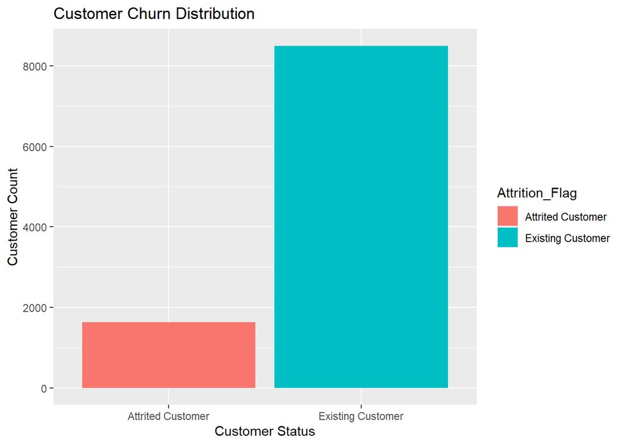

```r
ggplot(churn,
       aes(x = Attrition_Flag,
           fill = Attrition_Flag)) +
  geom_bar() +
  labs(
    title = "Customer Churn Distribution",
    x = "Customer Status",
    y = "Customer Count"
  )
```

## Observation

The dataset is imbalanced because the number of existing customers is substantially larger than the number of churned customers.

# Data Preparation

The target variable is converted into binary form.

```r
churn$Attrition_Flag <- ifelse(
  churn$Attrition_Flag == "Attrited Customer",
  1,
  0
)

table(churn$Attrition_Flag)
```

```
##
##    0    1
## 8500 1627
```

Where:

- 0 = Existing Customer
- 1 = Attrited Customer

# Exploratory Data Analysis

## Customer Age Distribution

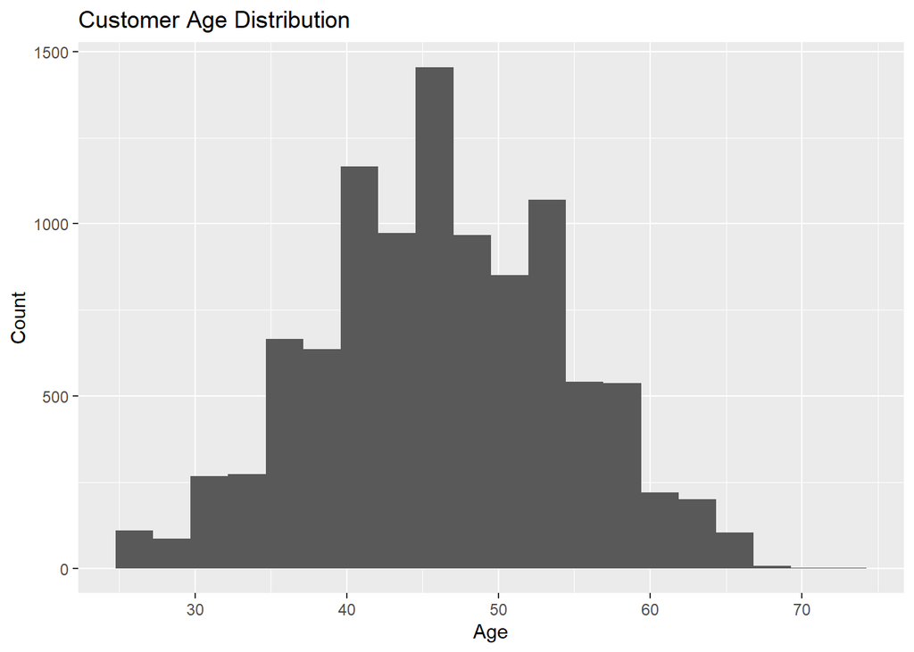

```r
ggplot(churn,
       aes(x = Customer_Age)) +
  geom_histogram(bins = 20) +
  labs(
    title = "Customer Age Distribution",
    x = "Age",
    y = "Count"
  )
```

## Observation

The majority of customers fall within the middle-age category.

# Churn by Gender

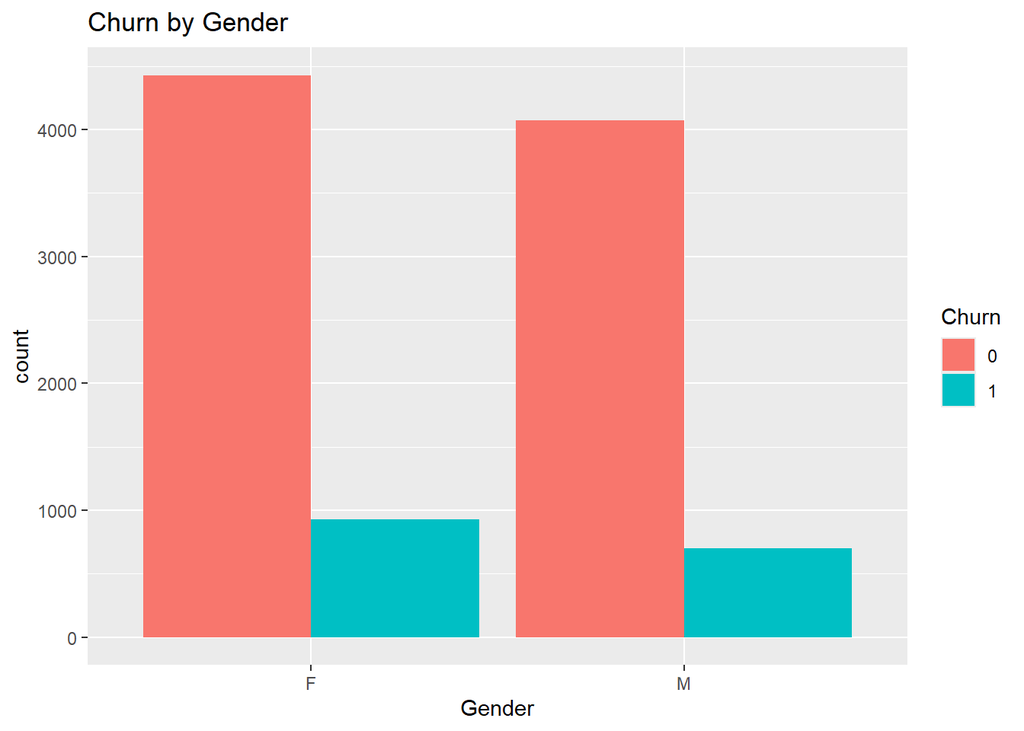

```r
ggplot(churn,
       aes(x = Gender,
           fill = factor(Attrition_Flag))) +
  geom_bar(position = "dodge") +
  labs(
    title = "Churn by Gender",
    x = "Gender",
    fill = "Churn"
  )
```

## Observation

This chart compares churn patterns across genders.

# Churn by Inactivity

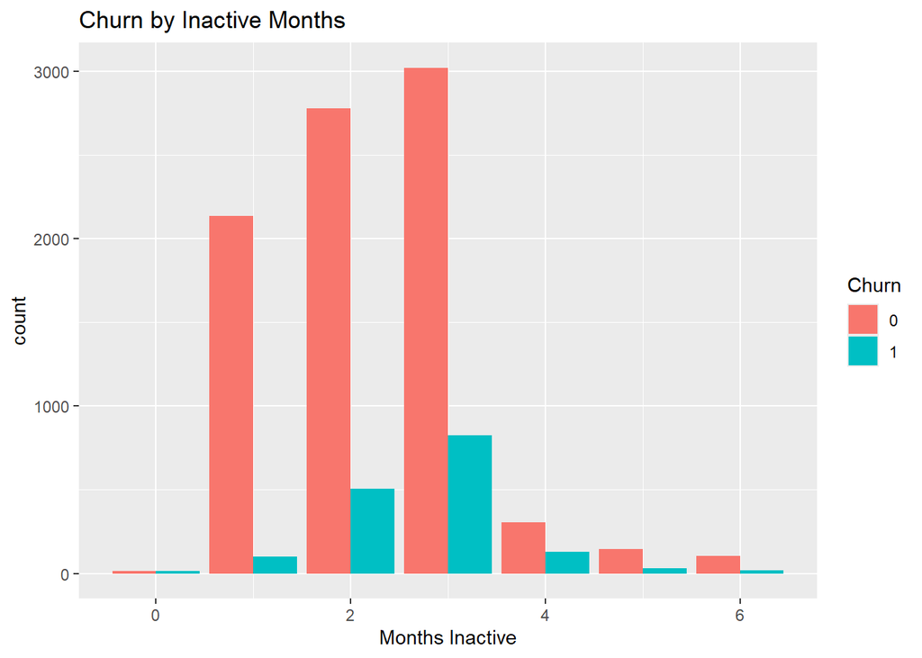

```r
ggplot(churn,
       aes(x = Months_Inactive_12_mon,
           fill = factor(Attrition_Flag))) +
  geom_bar(position = "dodge") +
  labs(
    title = "Churn by Inactive Months",
    x = "Months Inactive",
    fill = "Churn"
  )
```

## Observation

Customers with higher inactivity levels appear more likely to churn.

# Logistic Regression

## Theory

Logistic Regression is a supervised machine learning algorithm used for binary classification problems. It predicts the probability of an event occurring.

In this project, Logistic Regression is used to predict whether a customer will churn.

# Building the Logistic Regression Model

```r
model <- glm(
  Attrition_Flag ~ Customer_Age +
    Total_Trans_Amt +
    Total_Trans_Ct +
    Months_Inactive_12_mon,
  data = churn,
  family = "binomial"
)

summary(model)
```

```
##
## Call:
## glm(formula = Attrition_Flag ~ Customer_Age + Total_Trans_Amt +
##     Total_Trans_Ct + Months_Inactive_12_mon, family = "binomial",
##     data = churn)
##
## Coefficients:
##                          Estimate Std. Error z value Pr(>|z|)
## (Intercept)             1.698e+00  2.133e-01   7.960 1.72e-15 ***
## Customer_Age           -1.222e-02  3.758e-03  -3.252  0.00115 **
## Total_Trans_Amt         4.112e-04  1.811e-05  22.713  < 2e-16 ***
## Total_Trans_Ct         -9.934e-02  2.846e-03 -34.910  < 2e-16 ***
## Months_Inactive_12_mon  4.913e-01  3.108e-02  15.809  < 2e-16 ***
## ---
## Signif. codes:  0 '***' 0.001 '**' 0.01 '*' 0.05 '.' 0.1 ' ' 1
##
## (Dispersion parameter for binomial family taken to be 1)
##
##     Null deviance: 8927.2  on 10126  degrees of freedom
## Residual deviance: 6648.9  on 10122  degrees of freedom
## AIC: 6658.9
##
## Number of Fisher Scoring iterations: 6
```

# Model Interpretation

The Logistic Regression model identified the following significant predictors:

- Customer Age
- Total Transaction Amount
- Total Transaction Count
- Months Inactive in Last 12 Months

## Key Findings

### Customer Age

Older customers are slightly less likely to churn.

### Total Transaction Count

Customers who perform more transactions are less likely to churn.

### Months Inactive

Customers with higher inactivity are more likely to churn.

### Total Transaction Amount

Transaction amount is a statistically significant predictor of churn.

# Model Predictions

```r
pred_prob <- predict(
  model,
  type = "response"
)

head(pred_prob)
```

```
##         1         2         3         4         5         6
## 0.1127969 0.2392458 0.5879033 0.8414602 0.3218140 0.4292041
```

# Customer Classification

```r
pred <- ifelse(
  pred_prob > 0.5,
  1,
  0
)

head(pred)
```

```
## 1 2 3 4 5 6
## 0 0 1 1 0 0
```

# Confusion Matrix

```r
table(pred,
      churn$Attrition_Flag)
```

```
##
## pred    0    1
##    0 8093 1320
##    1  407  307
```

## Interpretation

The confusion matrix compares actual customer outcomes with model predictions.

It provides information about:

- Correctly predicted customers
- Incorrectly predicted customers
- Model performance

# Model Accuracy

```r
accuracy <- mean(
  pred == churn$Attrition_Flag
)

accuracy
```

```
## [1] 0.8294658
```

## Observation

The model achieved approximately 83% accuracy.

# Business Insights

The analysis generated the following insights:

1. Customer inactivity is a strong indicator of churn.
2. Customers with lower transaction activity are more likely to leave.
3. Younger customers exhibit slightly higher churn tendencies.
4. Customer engagement plays an important role in retention.

# Power BI Dashboard

## Dashboard Overview

An interactive Power BI dashboard was developed to visualize customer churn patterns and support decision-making.

Dashboard Components:

Dashboard slicers were created for:

- Gender
- Income Category
- Card Category

These slicers allow users to interactively filter customer segments and explore churn behavior.

## Power BI Dashboard

### Dashboard Overview

The Power BI dashboard provides an interactive view of customer churn patterns and key performance indicators.

### Figure 1: Overall Dashboard

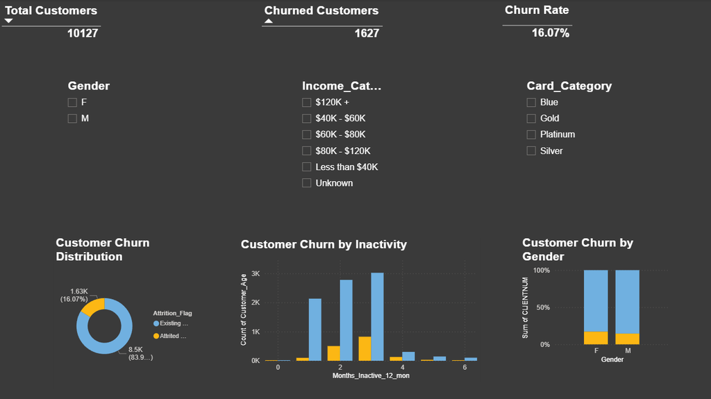

### Figure 2: Filtered Dashboard

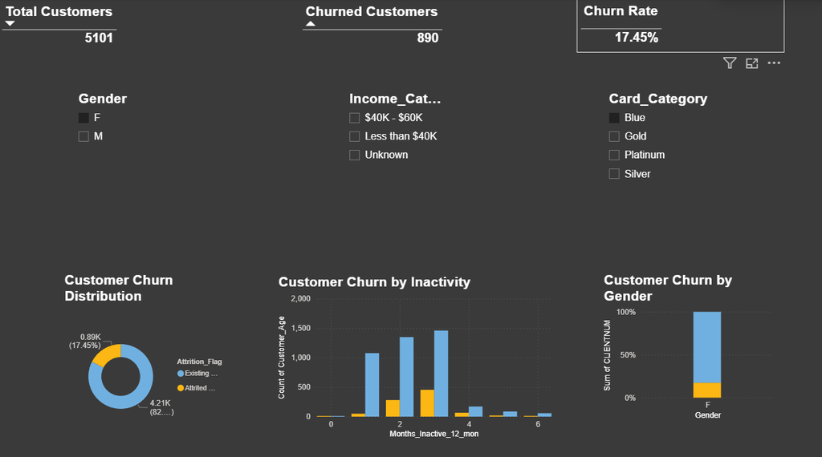

The dashboard allows users to filter customer data by gender, income category, and card category, enabling deeper analysis of churn behavior across customer segments.

# Recommendations

Based on the analysis, the following recommendations are proposed:

1. Monitor inactive customers proactively.
2. Develop retention campaigns targeting low-activity customers.
3. Introduce loyalty programs to encourage customer engagement.
4. Use predictive analytics to identify high-risk customers before they churn.

# Conclusion

This project used Logistic Regression in R and dashboard visualization in Power BI to analyze customer churn behavior.

The model identified customer inactivity and transaction activity as important drivers of churn. The analysis demonstrated how predictive analytics can help organizations understand customer behavior and support data-driven retention strategies.

The model achieved approximately 83% accuracy and provided actionable business insights for reducing customer attrition.